# Get started

The aim of the package `chessboard` is to provide tools to work with **directed** (asymmetric) and **undirected** (symmetrical) spatial (or non-spatial) **networks**. It implements different methods to detect neighbors, all based on the chess game (it goes beyond the rook and the queen available in many R packages) to create complex connectivity scenarios.

`chessboard` aims to easily create various network objects, including:

- **node list**, i.e. a list of all nodes of the network;
- **edge list**, i.e. a list of all edges (links) between pairs of nodes;
- **connectivity matrix**, i.e. a binary matrix of dimensions `n x n`, where `n` is the number of **nodes** (sampling units) indicating the presence (`1`) or the absence (`0`) of an **edge** (link) between pairs of nodes.

```r
# Setup ----
library("chessboard")
library("ggplot2")
library("patchwork")
```

## Network properties

`chessboard` can handle spatial networks, but it does not explicitly use geographical coordinates to find neighbors (it is not based on spatial distance). Instead, it identifies neighbors according to **node labels** (i.e. the node position on a two-dimension chessboard) and a specific method (pawn, fool, rook, bishop, knight, queen, wizard, etc.) derived from the chess game.

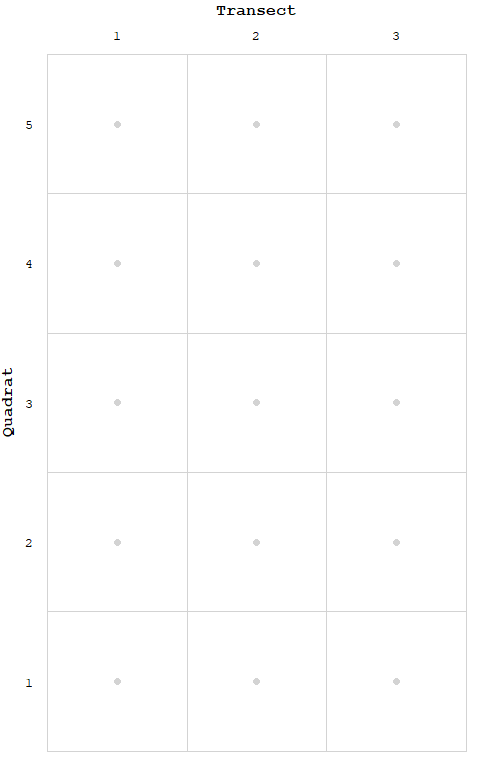

Figure 1. Network as a chessboard

The package `chessboard` is designed to work with two-dimensional networks (i.e. sampling on a regular grid), where one dimension is called **transect** and the other is called **quadrat**. By convention, the dimension **transect** corresponds to the x-axis, and the **quadrat** corresponds to the y-axis (Fig. 1).

`chessboard` can also deal with one-dimensional network (either **transect-only** or **quadrat-only**).

The network can be undirected or directed. If the network is **directed**, it will have (by default) these two orientations:

- from bottom to top (along transect) for quadrats
- from left to right (along quadrat) for transects

## Neighbors detection

`chessboard` implements the following rules to detect neighbors and to create edges:

- the **degree** of neighborhood: the number of adjacent nodes that will be used to create direct edges.
- the **orientation** of neighborhood: can neighbors be detected horizontally, vertically and/or diagonally?
- the **direction** of neighborhood: does the sampling has a main direction? This can be particularly relevant for directed networks (e.g. rivers).

## Workflow

The Figure 2 shows the general workflow and the main features of `chessboard`.

[figure not shown]

Figure 2. Workflow and main features of `chessboard`

### Data

The package `chessboard` comes with a real-world example: a survey sampling along the French river *L’Adour* (Fig. 3). *L’Adour* is a river in southwestern France. It rises in the Pyrenees and flows into the Atlantic Ocean (Bay of Biscay). It’s oriented from south-east (upstream) to north-west (downstream).

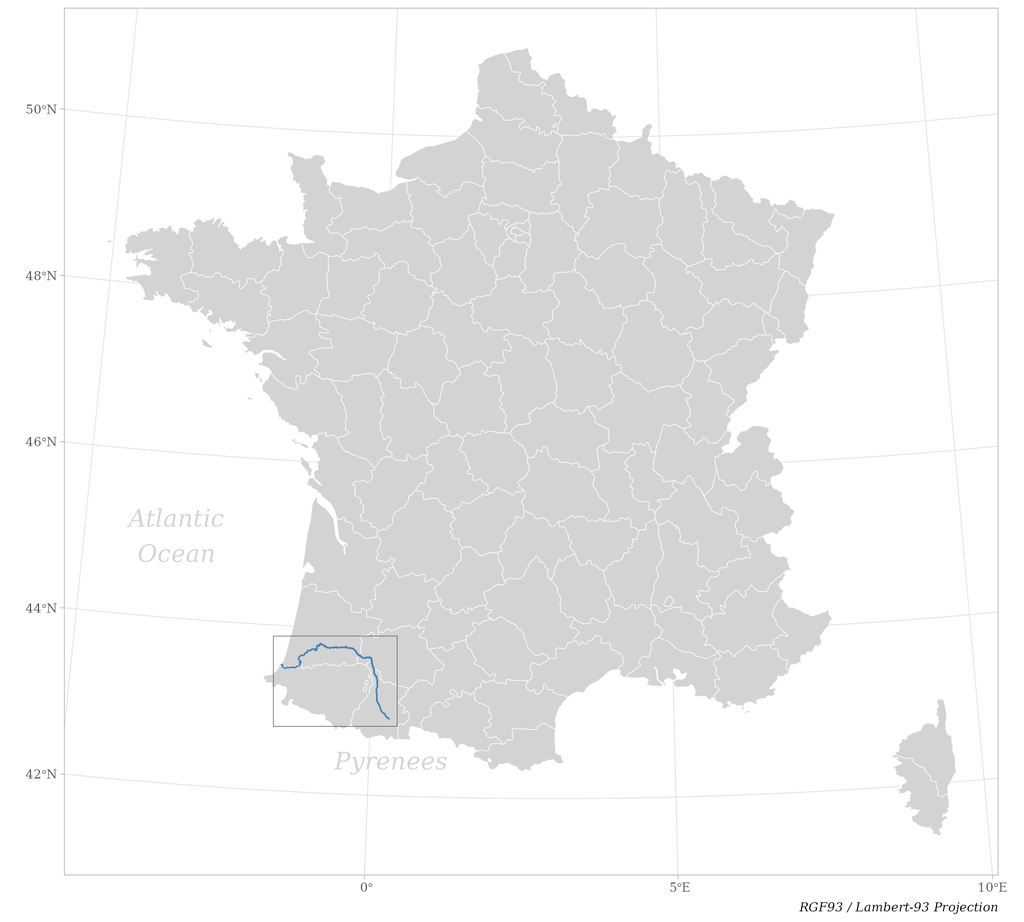

Figure 3. Location of the French river L’Adour

Along this river, a survey has been realized at **three** locations (Fig. 4). At each location, a sampling has been conducted on a regular grid composed of **three** transects each of them composed of **five** quadrats.

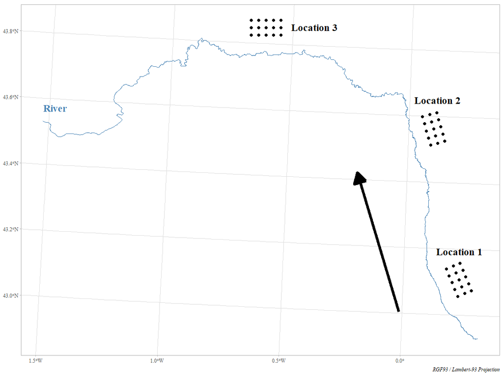

Figure 4. Survey sampling along the river L’Adour

The arrow in Fig. 4 indicates the direction of the river flow. This means that our sampling design is a **directed spatial network** (both inside a location and between locations) where the main direction is from upstream to downstream.

Let’s import this dataset provided by `chessboard`.

```r
# Import data ----
path_to_file <- system.file("extdata", "adour_survey_sampling.csv",
                            package = "chessboard")

sampling  <- read.csv(path_to_file)

dim(sampling)
```

```
#> [1] 45  5
```

```r
# First rows ----
head(sampling, 10)
```

```
#>    location transect quadrat longitude latitude
#> 1         1        1       1  474036.9  6221518
#> 2         1        1       2  473080.0  6223828
#> 3         1        1       3  472123.1  6226138
#> 4         1        1       4  471166.2  6228448
#> 5         1        1       5  470209.3  6230758
#> 6         1        2       1  476347.0  6222475
#> 7         1        2       2  475390.1  6224785
#> 8         1        2       3  474433.2  6227095
#> 9         1        2       4  473476.3  6229405
#> 10        1        2       5  472519.5  6231715
```

```r
# Last rows ----
tail(sampling, 10)
```

```
#>    location transect quadrat longitude latitude
#> 36        3        2      11  414434.2  6312095
#> 37        3        2      12  411933.7  6312095
#> 38        3        2      13  409433.2  6312095
#> 39        3        2      14  406932.8  6312095
#> 40        3        2      15  404432.3  6312095
#> 41        3        3      11  414434.2  6314595
#> 42        3        3      12  411933.7  6314595
#> 43        3        3      13  409433.2  6314595
#> 44        3        3      14  406932.8  6314595
#> 45        3        3      15  404432.3  6314595
```

This `data.frame` contains the following columns:

- `location`: the identifier of the location (`numeric`)
- `transect`: the identifier of the transect (`numeric`)
- `quadrat`: the identifier of the quadrat (`numeric`)
- `longitude`: the longitude of the site (**node**) defined in the [RGF93 / Lambert-93](https://epsg.io/2154) projection
- `latitude`: the latitude of the site (**node**) defined in the [RGF93 / Lambert-93](https://epsg.io/2154) projection

**N.B.** The column `location` is optional if the survey has been conducted at one single location. If the network has one dimension, one of the columns `transect` and `quadrat` can be omitted. If the survey is not spatial, the columns `longitude` and `latitude` can be omitted.

### Node labels

When working with `chessboard`, the **first step** is to create node labels with the function `create_node_labels()`.

But first, let’s reduce the size of data by selecting the first location.

```r
# Select the first location ----
sampling <- sampling[sampling$"location" == 1, ]

dim(sampling)
```

```
#> [1] 15  5
```

Let’s create node labels with the function `create_node_labels()`.

```r
# Create node labels ----
nodes <- create_node_labels(data     = sampling,
                            location = "location",
                            transect = "transect",
                            quadrat  = "quadrat")

nodes
```

```
#>    node location transect quadrat longitude latitude
#> 1   1-1        1        1       1  474036.9  6221518
#> 2   1-2        1        1       2  473080.0  6223828
#> 3   1-3        1        1       3  472123.1  6226138
#> 4   1-4        1        1       4  471166.2  6228448
#> 5   1-5        1        1       5  470209.3  6230758
#> 6   2-1        1        2       1  476347.0  6222475
#> 7   2-2        1        2       2  475390.1  6224785
#> 8   2-3        1        2       3  474433.2  6227095
#> 9   2-4        1        2       4  473476.3  6229405
#> 10  2-5        1        2       5  472519.5  6231715
#> 11  3-1        1        3       1  478657.1  6223432
#> 12  3-2        1        3       2  477700.2  6225742
#> 13  3-3        1        3       3  476743.4  6228052
#> 14  3-4        1        3       4  475786.5  6230362
#> 15  3-5        1        3       5  474829.6  6232672
```

Node labels are a combination of the transect and the quadrat identifiers. They must be **unique**.

We can visualize this sampling on a Cartesian referential, i.e. non-spatial, where the x-axis corresponds to **transects** and the y-axis represents the **quadrats** (Fig. 5). This new referential is called a chessboard.

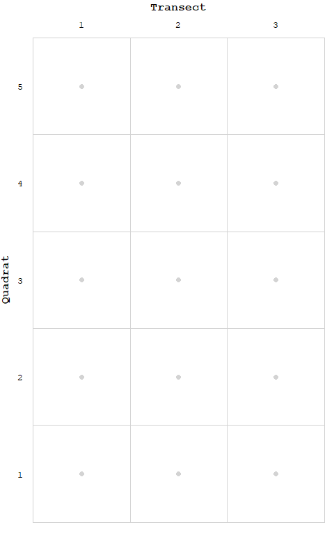

Figure 5. Sampling survey as a chessboard

```r
# Visualize chessboard ----
gg_chessboard(nodes)
```

The function `get_node_list()` can be used to extract and order the node list.

```r
# Extract node labels ----
get_node_list(nodes)
```

```
#>  [1] "1-1" "1-2" "1-3" "1-4" "1-5" "2-1" "2-2" "2-3" "2-4" "2-5" "3-1" "3-2"
#> [13] "3-3" "3-4" "3-5"
```

### Edge list

The creation of a list of edges (links) between nodes (sampling units) is based on the detection of neighbors.

In `chessboard` different methods have been implemented to define neighborhood (argument `method` of the function `create_edge_list()`). These methods are named `'pawn'`, `'rook'`, `'bishop'`, `'queen'`, etc. A complete list of available methods is available at: https://frbcesab.github.io/chessboard/reference/index.html#detect-neighbors

Before using the function `create_edge_list()`, users can explore these different methods by calling the functions `pawn()`, `rook()`, `bishop()`, `queen()`, etc. These functions only work on a specific node (argument `focus`).

Let’s take a look of the neighborhood method `pawn()`.

```r
# Explore pawn method to find neighbors ----
neighbors_pawn <- pawn(nodes    = nodes,
                       focus    = "2-3",
                       degree   = 1,
                       directed = FALSE,
                       reverse  = FALSE)
neighbors_pawn
```

```
#>   node location transect quadrat longitude latitude
#> 1  2-2        1        2       2  475390.1  6224785
#> 2  2-4        1        2       4  473476.3  6229405
```

The package `chessboard` contains functions to visualize detected neighbors on a chessboard: `gg_chessboard()` is used to plot a chessboard (dimensions defined by the node list), `geom_node()` emphasizes the focus node (in red), and `geom_neighbors()` adds the detected neighbors (dots in black).

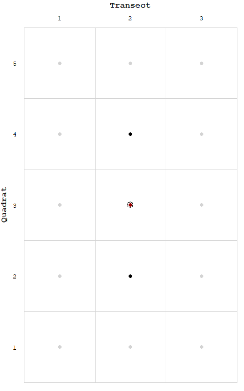

Figure 6. Detected neighbors (pawn method)

```r
gg_chessboard(nodes) +
  geom_node(nodes, focus = "2-3") +
  geom_neighbors(nodes, neighbors_pawn)
```

The function `pawn()` can detect neighbors vertically, i.e. among quadrats along a transect. User can change the default settings by increasing the degree of neighborhood (`degree = 4`, Fig. 7A), by adding directionality (`directed = TRUE`, Fig. 7B), and by reversing the default directionality (`directed = TRUE` and `reverse = TRUE`, Fig. 7C).

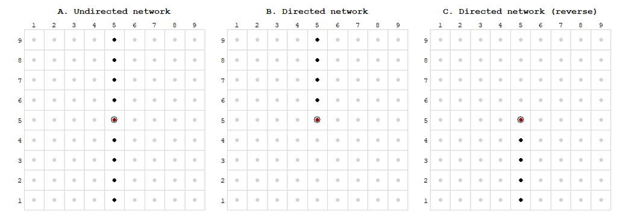

Figure 7. Pawn movements

Let’s take another example. The function `bishop()` can detect neighbors diagonally. User can change the default settings by increasing the degree of neighborhood (`degree = 4`, Fig. 8A), by adding directionality (`directed = TRUE`, Fig. 8B), and by reversing the default directionality (`directed = TRUE` and `reverse = TRUE`, Fig. 8C).

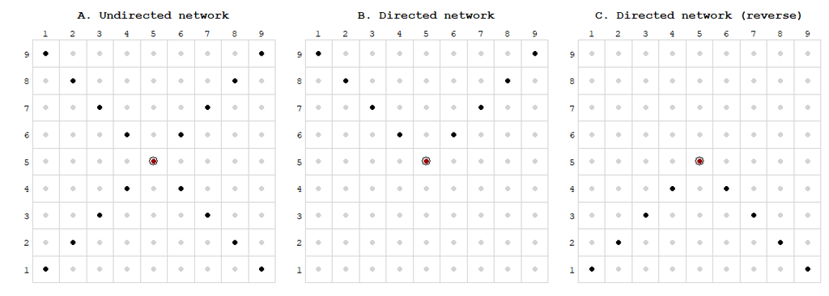

Figure 8. Bishop movements

The vignette [Chess pieces](https://frbcesab.github.io/chessboard/articles/chess-pieces.html) shows all possible methods available in `chessboard`.

Now, let’s use the function `create_edge_list()` to create an edge list using the method `'pawn'` with a degree `1` of neighborhood and in a directional way.

```r
# Create edge list ----
edges_pawn <- create_edge_list(nodes    = nodes,
                               method   = "pawn",
                               degree   = 1,
                               directed = TRUE,
                               reverse  = FALSE,
                               self     = FALSE)

edges_pawn
```

```
#>    from  to
#> 1   1-1 1-2
#> 2   1-2 1-3
#> 3   1-3 1-4
#> 4   1-4 1-5
#> 5   2-1 2-2
#> 6   2-2 2-3
#> 7   2-3 2-4
#> 8   2-4 2-5
#> 9   3-1 3-2
#> 10  3-2 3-3
#> 11  3-3 3-4
#> 12  3-4 3-5
```

It’s possible to visualize these edges on a map, i.e. by using spatial coordinates. First, we need to convert our sites into a spatial object (`POINT`).

```r
# Convert nodes to sf object ----
nodes_sf <- sf::st_as_sf(nodes, coords = c("longitude", "latitude"),
                               crs = "epsg:2154")

head(nodes_sf)
```

```
#> Simple feature collection with 6 features and 4 fields
#> Geometry type: POINT
#> Dimension:     XY
#> Bounding box:  xmin: 470209.3 ymin: 6221518 xmax: 476347 ymax: 6230758
#> Projected CRS: RGF93 v1 / Lambert-93
#>   node location transect quadrat                 geometry
#> 1  1-1        1        1       1 POINT (474036.9 6221518)
#> 2  1-2        1        1       2   POINT (473080 6223828)
#> 3  1-3        1        1       3 POINT (472123.1 6226138)
#> 4  1-4        1        1       4 POINT (471166.2 6228448)
#> 5  1-5        1        1       5 POINT (470209.3 6230758)
#> 6  2-1        1        2       1   POINT (476347 6222475)
```

Now we can use the function `edges_to_sf()` to convert our edge list into a spatial object (`LINESTRING`).

```r
# Convert edge list to sf ----
edges_pawn_sf <- edges_to_sf(edges = edges_pawn,
                             sites = nodes_sf)

edges_pawn_sf
```

```
#> Simple feature collection with 12 features and 2 fields
#> Geometry type: LINESTRING
#> Dimension:     XY
#> Bounding box:  xmin: 470209.3 ymin: 6221518 xmax: 478657.1 ymax: 6232672
#> Projected CRS: RGF93 v1 / Lambert-93
#> First 10 features:
#>    from  to                       geometry
#> 1   1-1 1-2 LINESTRING (474036.9 622151...
#> 2   1-2 1-3 LINESTRING (473080 6223828,...
#> 3   1-3 1-4 LINESTRING (472123.1 622613...
#> 4   1-4 1-5 LINESTRING (471166.2 622844...
#> 5   2-1 2-2 LINESTRING (476347 6222475,...
#> 6   2-2 2-3 LINESTRING (475390.1 622478...
#> 7   2-3 2-4 LINESTRING (474433.2 622709...
#> 8   2-4 2-5 LINESTRING (473476.3 622940...
#> 9   3-1 3-2 LINESTRING (478657.1 622343...
#> 10  3-2 3-3 LINESTRING (477700.2 622574...
```

We can now map our nodes and edges.

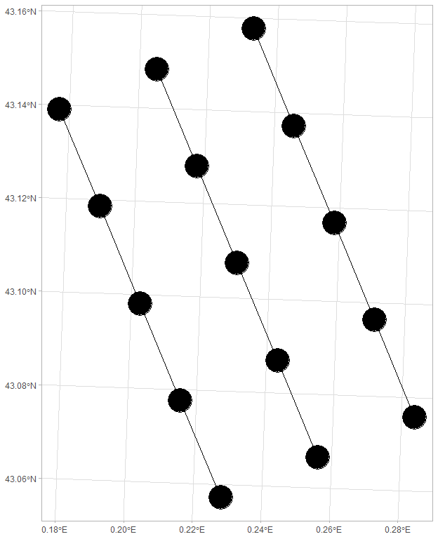

Figure 9. Edge list (pawn method)

```r
# Map of nodes and edges ----
ggplot(nodes_sf) +
  geom_sf(size = 12) +
  geom_sf(data = edges_pawn_sf) +
  theme_light()
```

Users may want to combine different methods to detect neighbors to build complex scenarios. It’s possible by using for each method the function `create_edge_list()` and using the function `append_edge_lists()` to merge all edges in a single list.

```r
# Create edge list (Bishop method) ----
edges_bishop <- create_edge_list(nodes    = nodes,
                                 method   = "bishop",
                                 degree   = 1,
                                 directed = TRUE,
                                 reverse  = FALSE,
                                 self     = FALSE)

edges_bishop
```

```
#>    from  to
#> 1   1-1 2-2
#> 2   1-2 2-3
#> 3   1-3 2-4
#> 4   1-4 2-5
#> 5   2-1 1-2
#> 6   2-1 3-2
#> 7   2-2 1-3
#> 8   2-2 3-3
#> 9   2-3 1-4
#> 10  2-3 3-4
#> 11  2-4 1-5
#> 12  2-4 3-5
#> 13  3-1 2-2
#> 14  3-2 2-3
#> 15  3-3 2-4
#> 16  3-4 2-5
```

```r
# Merge Pawn and Bishop edges ----
edges <- append_edge_lists(edges_pawn, edges_bishop)

# Convert edges to spatial layer ----
edges_sf <- edges_to_sf(edges, nodes_sf)
```

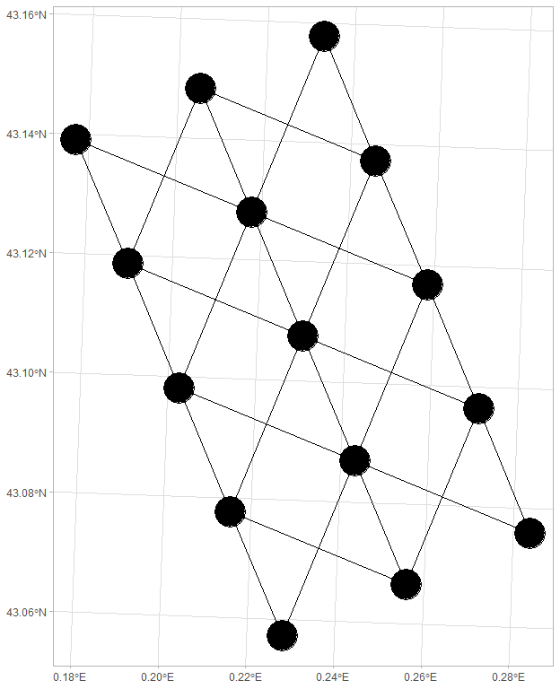

Figure 10. Edges list (combined methods)

```r
# Map of nodes and edges ----
ggplot(nodes_sf) +
  geom_sf(size = 12) +
  geom_sf(data = edges_sf) +
  theme_light()
```

### Connectivity matrix

From this edge list, we can build a **connectivity matrix**, i.e. a binary matrix of dimensions `n x n`, where `n` is the number of nodes (sampling units) indicating the presence (`1`) or the absence (`0`) of an edge (link) between pairs of nodes.

We can use the function `connectivity_matrix()` of the package `chessboard`.

```r
# Create connectivity matrix ----
conn_matrix <- connectivity_matrix(edges)

conn_matrix
```

```
#>     1-1 1-2 1-3 1-4 1-5 2-1 2-2 2-3 2-4 2-5 3-1 3-2 3-3 3-4 3-5
#> 1-1   0   1   0   0   0   0   1   0   0   0   0   0   0   0   0
#> 1-2   0   0   1   0   0   0   0   1   0   0   0   0   0   0   0
#> 1-3   0   0   0   1   0   0   0   0   1   0   0   0   0   0   0
#> 1-4   0   0   0   0   1   0   0   0   0   1   0   0   0   0   0
#> 1-5   0   0   0   0   0   0   0   0   0   0   0   0   0   0   0
#> 2-1   0   1   0   0   0   0   1   0   0   0   0   1   0   0   0
#> 2-2   0   0   1   0   0   0   0   1   0   0   0   0   1   0   0
#> 2-3   0   0   0   1   0   0   0   0   1   0   0   0   0   1   0
#> 2-4   0   0   0   0   1   0   0   0   0   1   0   0   0   0   1
#> 2-5   0   0   0   0   0   0   0   0   0   0   0   0   0   0   0
#> 3-1   0   0   0   0   0   0   1   0   0   0   0   1   0   0   0
#> 3-2   0   0   0   0   0   0   0   1   0   0   0   0   1   0   0
#> 3-3   0   0   0   0   0   0   0   0   1   0   0   0   0   1   0
#> 3-4   0   0   0   0   0   0   0   0   0   1   0   0   0   0   1
#> 3-5   0   0   0   0   0   0   0   0   0   0   0   0   0   0   0
```

The package `chessboard` provides a function to visualize this matrix: `gg_matrix()`.

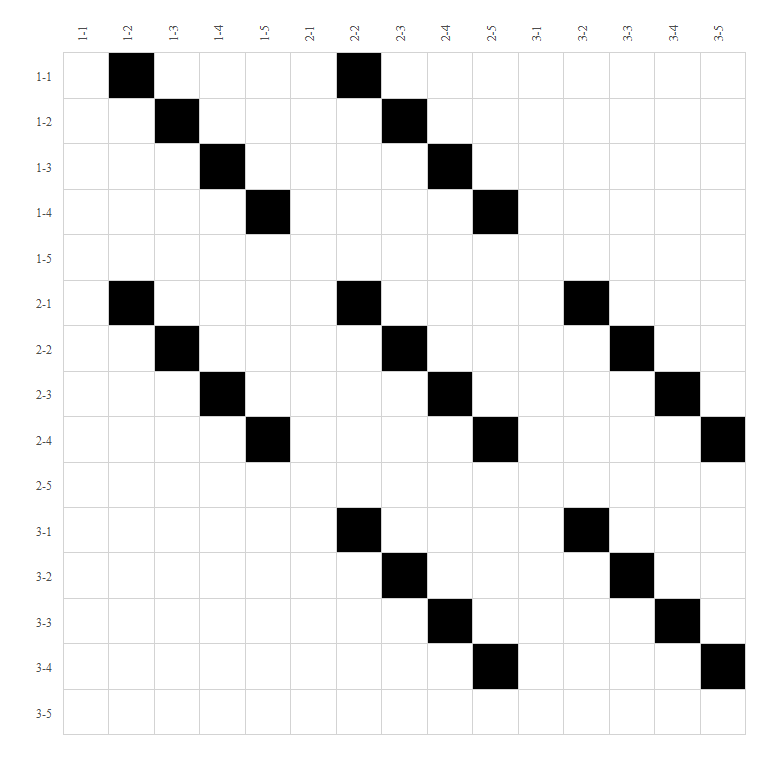

Figure 11. Connectivity matrix

```r
# Visualize connectivity matrix ----
gg_matrix(conn_matrix)
```

Optionally, we can use the function `matrix_to_edge_list()` to convert back the connectivity matrix to edge list.

```r
# Convert connectivity matrix to edge list ----
matrix_to_edge_list(conn_matrix)
```

```
#>    from  to edge
#> 1   1-1 1-2    1
#> 2   1-1 2-2    1
#> 3   1-2 1-3    1
#> 4   1-2 2-3    1
#> 5   1-3 1-4    1
#> 6   1-3 2-4    1
#> 7   1-4 1-5    1
#> 8   1-4 2-5    1
#> 9   2-1 1-2    1
#> 10  2-1 2-2    1
#> 11  2-1 3-2    1
#> 12  2-2 1-3    1
#> 13  2-2 2-3    1
#> 14  2-2 3-3    1
#> 15  2-3 1-4    1
#> 16  2-3 2-4    1
#> 17  2-3 3-4    1
#> 18  2-4 1-5    1
#> 19  2-4 2-5    1
#> 20  2-4 3-5    1
#> 21  3-1 2-2    1
#> 22  3-1 3-2    1
#> 23  3-2 2-3    1
#> 24  3-2 3-3    1
#> 25  3-3 2-4    1
#> 26  3-3 3-4    1
#> 27  3-4 2-5    1
#> 28  3-4 3-5    1
```

## Extending chessboard

`chessboard` has been built to be compatible with the following R packages: [`igraph`](https://r.igraph.org/) (Csardi & Nepusz 2006), [`sf`](https://r-spatial.github.io/sf/) (Pebesma 2018), and [`ggplot2`](https://ggplot2.tidyverse.org) (Wickham 2016).

### with `sf`

As seen before, the edge list can be converted into an spatial object with the function `edges_to_sf()`. The output is an `sf` `LINESTRING` that can be handled by many functions of the package `sf`. For instance, let’s project the coordinate system.

```r
# Convert edges to spatial layer ----
edges_sf <- edges_to_sf(edges, nodes_sf)

# Project the CRS ----
edges_sf_lonlat <- sf::st_transform(edges_sf, crs = "epsg:4326")

# Check ----
edges_sf
```

```
#> Simple feature collection with 28 features and 2 fields
#> Geometry type: LINESTRING
#> Dimension:     XY
#> Bounding box:  xmin: 470209.3 ymin: 6221518 xmax: 478657.1 ymax: 6232672
#> Projected CRS: RGF93 v1 / Lambert-93
#> First 10 features:
#>    from  to                       geometry
#> 1   1-1 1-2 LINESTRING (474036.9 622151...
#> 2   1-1 2-2 LINESTRING (474036.9 622151...
#> 3   1-2 1-3 LINESTRING (473080 6223828,...
#> 4   1-2 2-3 LINESTRING (473080 6223828,...
#> 5   1-3 1-4 LINESTRING (472123.1 622613...
#> 6   1-3 2-4 LINESTRING (472123.1 622613...
#> 7   1-4 1-5 LINESTRING (471166.2 622844...
#> 8   1-4 2-5 LINESTRING (471166.2 622844...
#> 9   2-1 1-2 LINESTRING (476347 6222475,...
#> 10  2-1 2-2 LINESTRING (476347 6222475,...
```

```r
edges_sf_lonlat
```

```
#> Simple feature collection with 28 features and 2 fields
#> Geometry type: LINESTRING
#> Dimension:     XY
#> Bounding box:  xmin: 0.1770395 ymin: 43.05727 xmax: 0.2838317 ymax: 43.15778
#> Geodetic CRS:  WGS 84
#> First 10 features:
#>    from  to                       geometry
#> 1   1-1 1-2 LINESTRING (0.2280052 43.05...
#> 2   1-1 2-2 LINESTRING (0.2280052 43.05...
#> 3   1-2 1-3 LINESTRING (0.2152773 43.07...
#> 4   1-2 2-3 LINESTRING (0.2152773 43.07...
#> 5   1-3 1-4 LINESTRING (0.2025404 43.09...
#> 6   1-3 2-4 LINESTRING (0.2025404 43.09...
#> 7   1-4 1-5 LINESTRING (0.1897944 43.11...
#> 8   1-4 2-5 LINESTRING (0.1897944 43.11...
#> 9   2-1 1-2 LINESTRING (0.2559139 43.06...
#> 10  2-1 2-2 LINESTRING (0.2559139 43.06...
```

User can also export this spatial layer.

```r
# Export layer as a GeoPackage ----
sf::st_write(edges_sf, "edge_list.gpkg")
```

For more information about the package `sf`, please visit the [manual](https://cran.r-project.org/package=sf).

### with `ggplot2`

All plotting functions in `chessboard` are produced with the `ggplot2` engine and are highly customizable. For instance, let’s change the default theme.

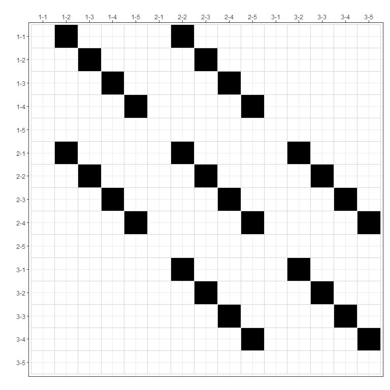

Figure 12. Custom connectivity matrix

```r
# Change default ggplot2 theme ----
gg_matrix(conn_matrix) +
  theme_bw() +
  theme(legend.position = "none")
```

For more information about the package `ggplot2`, please visit the [manual](https://cran.r-project.org/package=ggplot2).

### with `igraph`

The package `igraph` is commonly use to analyze network data. User can use the function `igraph::graph_from_data_frame()` to convert the edge list created with `chessboard` to an `igraph` object.

```r
# Convert edge list to igraph object ----
igraph_obj <- igraph::graph_from_data_frame(d        = edges,
                                            directed = TRUE,
                                            vertices = nodes)

# Check -----
class(igraph_obj)
```

```
#> [1] "igraph"
```

```r
print(igraph_obj)
```

```
#> IGRAPH cfe0b1d DN-- 15 28 --
#> + attr: name (v/c), location (v/n), transect (v/n), quadrat (v/n),
#> | longitude (v/n), latitude (v/n)
#> + edges from cfe0b1d (vertex names):
#>  [1] 1-1->1-2 1-1->2-2 1-2->1-3 1-2->2-3 1-3->1-4 1-3->2-4 1-4->1-5 1-4->2-5
#>  [9] 2-1->1-2 2-1->2-2 2-1->3-2 2-2->1-3 2-2->2-3 2-2->3-3 2-3->1-4 2-3->2-4
#> [17] 2-3->3-4 2-4->1-5 2-4->2-5 2-4->3-5 3-1->2-2 3-1->3-2 3-2->2-3 3-2->3-3
#> [25] 3-3->2-4 3-3->3-4 3-4->2-5 3-4->3-5
```

Let’s plot our network using `igraph`.

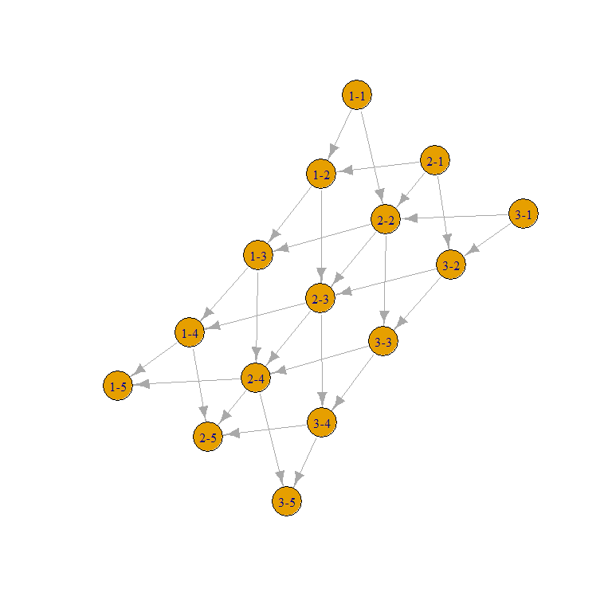

Figure 13. Network visualization w/ `igraph`

```r
# Plot the network w/ igraph ----
plot(igraph_obj)
```

For more information about the package `igraph`, please visit the [manual](https://cran.r-project.org/package=igraph).

## References

Bivand R & Wong D (2018) Comparing implementations of global and local indicators of spatial association. **TEST**, 27, 716–748. https://doi.org/10.1007/s11749-018-0599-x.

Csardi G & Nepusz T (2006) The igraph software package for complex network research. **InterJournal, Complex Systems**, 1695, 1–9. https://igraph.org/.

Pebesma E (2018) Simple Features for R: Standardized support for spatial vector data. **The R Journal**, 10, 439–446. https://doi.org/10.32614/RJ-2018-009.

Wickham H (2016) *ggplot2: Elegant graphics for data analysis* (p. 213). Springer-Verlag. https://ggplot2.tidyverse.org/.